# Project 6019

2025-08-14

The below will be kept for all the directories which are required to run the model.

Loading the three data files. Used the same name as the files to keep things simple.

```r
delay <- read.csv("delay.csv")
delay_covariates <- read.csv("delay_covariates.csv")
survey <- read.csv("survey.csv")
```

Checking the structure of “delay”.

```r
str(delay)
```

```
## 'data.frame':    215163 obs. of  18 variables:
##  $ program              : chr  "DHS" "DHS" "DHS" "DHS" ...
##  $ phase                : chr  "DHS5" "DHS5" "DHS5" "DHS5" ...
##  $ surveyid             : int  222 264 264 264 264 264 264 264 264 264 ...
##  $ regionid             : int  7 27 7 29 23 29 7 27 24 8 ...
##  $ districtid           : int  NA NA NA NA NA NA NA NA NA NA ...
##  $ clusterid            : int  244 27138 7104 29020 23172 29079 7066 27059 24108 8060 ...
##  $ respondentid         : chr  "      244510  2" "   27138  21  5" "    7104  21  4" "   29 20   4  2" ...
##  $ childid              : int  1 1 1 1 1 1 2 1 1 1 ...
##  $ drug_base            : chr  "[\"fever/cough\"]" "[\"fever/cough\"]" "[\"fever/cough\"]" "[\"fever/cough\"]" ...
##  $ days_to_seek         : chr  "" "0" "0" "1" ...
##  $ source_type          : chr  "[\"home\"]" "[\"other\"]" "[\"other\"]" "[\"other\", \"other\"]" ...
##  $ source_sector        : chr  "[\"nonmedical\"]" "[\"not home\"]" "[\"not home\"]" "[\"not home\", \"not home\"]" ...
##  $ days_to_antimalarial : int  NA NA NA NA NA NA NA NA NA NA ...
##  $ days_to_act          : int  NA NA NA NA NA NA NA NA NA NA ...
##  $ antimalarial_duration: int  NA NA NA NA NA NA NA NA NA NA ...
##  $ act_duration         : logi  NA NA NA NA NA NA ...
##  $ raw_data             : chr  "{\"ml16c\": \"1\"}" "{\"ml22c\": \"0\"}" "{\"ml15c\": \"0\"}" "{\"ml16c\": \"0\", \"ml20c\": \"0\"}" ...
##  $ answers              : chr  "{\"first source for chloroquine\": \"At home\"}" "{\"first source for unknown anti-malarial\": \"other source\"}" "{\"first source for fansidar\": \"other source\"}" "{\"first source for combination with artemisinin\": \"other source\", \"first source for chloroqui…
```

Checking the structure of “delayed_covariates”

```r
str(delay_covariates)
```

```
## 'data.frame':    716265 obs. of  40 variables:
##  $ program              : chr  "DHS" "DHS" "DHS" "DHS" ...
##  $ surveyid             : int  421 300 302 425 438 324 450 465 474 451 ...
##  $ regionid             : int  5 6 3 1 4 2 1 5 2 3 ...
##  $ districtid           : int  NA NA NA NA NA NA NA NA NA NA ...
##  $ clusterid            : int  79 331 55 176 552 102 118 138 80 597 ...
##  $ latitude             : num  -6.603 0.738 12.555 NA 6.402 ...
##  $ longitude            : num  22.43 35.51 7.73 NA 7.93 ...
##  $ respondentid         : chr  "        7916  2" "      331193  2" "       55 27  2" "       17616  4" ...
##  $ childid              : int  2 1 2 1 2 1 2 1 1 1 ...
##  $ base                 : chr  "fever/cough" "fever/cough" "fever/cough" "fever/cough" ...
##  $ fever                : chr  "no" "no" "yes" "yes" ...
##  $ cough                : chr  "yes" "yes" "no" "yes" ...
##  $ rapid_breathing      : chr  "no" "no" "" "yes" ...
##  $ chest_or_nose        : chr  "" "" "" "nose" ...
```

[output cut: 26 more lines]

Checking the structure of “survey”

```r
str(survey)
```

```
## 'data.frame':    593 obs. of  15 variables:
##  $ phase          : chr  "DHS1" "DHS1" "DHS1" "DHS1" ...
##  $ program        : chr  "DHS" "DHS" "DHS" "DHS" ...
##  $ surveyid       : int  1 2 3 4 5 6 7 8 9 11 ...
##  $ surveyname     : chr  "ES1985DHS" "BR1986DHS" "SN1986DHS" "CO1986DHS" ...
##  $ nid            : int  19533 19027 20749 19333 21412 20617 20180 20573 19647 20326 ...
##  $ surveytype     : chr  "DHS" "DHS" "DHS" "DHS" ...
##  $ language       : chr  "en" "en" "en" "en" ...
##  $ region         : chr  "Latin America & Caribbean" "Latin America & Caribbean" "Sub-Saharan Africa" "Latin America & Caribbean" ...
##  $ subregion      : chr  "Central America" "South America" "Western Africa" "South America" ...
##  $ country        : chr  "El Salvador" "Brazil" "Senegal" "Colombia" ...
##  $ iso3           : chr  "SLV" "BRA" "SEN" "COL" ...
##  $ survey_subset  : chr  "" "" "" "" ...
##  $ surveyyearlabel: chr  "1985" "1986" "1986" "1986" ...
##  $ year           : int  1985 1986 1986 1986 1986 1986 1986 1986 1987 1987 ...
##  $ url            : chr  "https://www.dhsprogram.com/pubs/pdf/FR15/FR15.pdf" "https://www.dhsprogram.com/pubs/pdf/FR4/FR4.pdf" "https://www.dhsprogram.com/pubs/pdf/FR34/FR34.pdf" "https://www.dhsprogram.com/pubs/pdf/FR8/FR8.pdf" ...
```

First, will find the common features between the first two datasets (delay, delay_covariates) Will be called common_col_del

```r
common_col_del <- intersect(colnames(delay), colnames(delay_covariates))
print(common_col_del)
```

```
## [1] "program"      "surveyid"     "regionid"     "districtid"   "clusterid"
## [6] "respondentid" "childid"
```

After that, will be combining the two datasets using those common features. Also fully merging to preserve all the data so later depends on the importance we can remove unwanted features. This will be called merged_del

```r
merged_del <- merge(delay, delay_covariates, by = c("program", "surveyid", "regionid", "districtid", "clusterid", "respondentid", "childid"), all= TRUE )
```

Finding common features between the new merged file and the survey data file will be called common_col

```r
common_col <- intersect(colnames(merged_del), colnames(survey))
print(common_col)
```

```
## [1] "program"    "surveyid"   "phase"      "surveyname" "country"
## [6] "region"     "subregion"
```

Combing the already combined dataset with the survey data creating one final dataset which includes all the data from all 3 separate data files. Also will be using the full merge method to combine all the data. This will be called merged.

```r
merged <- merge(merged_del, survey, by = c("program", "surveyid", "phase", "surveyname", "country", "region", "subregion"), all = TRUE)
```

Checking the structure of the newly merged full document to get an idea

```r
str(merged)
```

```
## 'data.frame':    754995 obs. of  59 variables:
##  $ program              : chr  "DHS" "DHS" "DHS" "DHS" ...
##  $ surveyid             : int  1 2 3 4 5 6 7 8 9 11 ...
##  $ phase                : chr  "DHS1" "DHS1" "DHS1" "DHS1" ...
##  $ surveyname           : chr  "ES1985DHS" "BR1986DHS" "SN1986DHS" "CO1986DHS" ...
##  $ country              : chr  "El Salvador" "Brazil" "Senegal" "Colombia" ...
##  $ region               : chr  "Latin America & Caribbean" "Latin America & Caribbean" "Sub-Saharan Africa" "Latin America & Caribbean" ...
##  $ subregion            : chr  "Central America" "South America" "Western Africa" "South America" ...
##  $ regionid             : int  NA NA NA NA NA NA NA NA NA NA ...
##  $ districtid           : int  NA NA NA NA NA NA NA NA NA NA ...
##  $ clusterid            : int  NA NA NA NA NA NA NA NA NA NA ...
##  $ respondentid         : chr  NA NA NA NA ...
##  $ childid              : int  NA NA NA NA NA NA NA NA NA NA ...
##  $ drug_base            : chr  NA NA NA NA ...
##  $ days_to_seek         : chr  NA NA NA NA ...
```

[output cut: 45 more lines]

Checking the missing values of longitude and latitude as it is the base of the project to map the data

```r
sum(is.na(merged$latitude))
```

```
## [1] 383598
```

```r
sum(is.na(merged$longitude))
```

```
## [1] 383598
```

Removing the data without a value for longitude and latitude merged1 is the data set without NA in long and lat

```r
merged1 <- merged[!is.na(merged$latitude) & !is.na(merged$longitude), ]
```

Filtering Africa from the countries merged2 is the data with only Africa in its data

```r
library(dplyr)
merged2 <- merged1 %>%
  filter(grepl("Africa", region, ignore.case = TRUE))
```

Count the cases based on the country

```r
country_count_all <- merged1 %>%
  count(country)
print(country_count_all)
```

```
##                      country     n
## 1                     Angola  5984
## 2                      Benin  5221
## 3               Burkina Faso 10616
## 4                    Burundi 12090
## 5                   Cameroon  8555
## 6                       Chad  4869
## 7                    Comoros   849
## 8  Congo Democratic Republic 11170
## 9              Cote d'Ivoire  4569
## 10                     Gabon  4552
## 11                    Gambia  2231
## 12                     Ghana  6496
## 13                    Guinea  4830
## 14                    Guyana   631
```

[output cut: 23 more lines]

```r
country_count <- merged2 %>%
  count(country)
print(country_count)
```

```
##                      country     n
## 1                     Angola  5984
## 2                      Benin  5221
## 3               Burkina Faso 10616
## 4                    Burundi 12090
## 5                   Cameroon  8555
## 6                       Chad  4869
## 7                    Comoros   849
## 8  Congo Democratic Republic 11170
## 9              Cote d'Ivoire  4569
## 10                     Gabon  4552
## 11                    Gambia  2231
## 12                     Ghana  6496
## 13                    Guinea  4830
## 14                     Kenya 18531
```

[output cut: 17 more lines]

Creating a bar chart with the countries and the cases, high to low

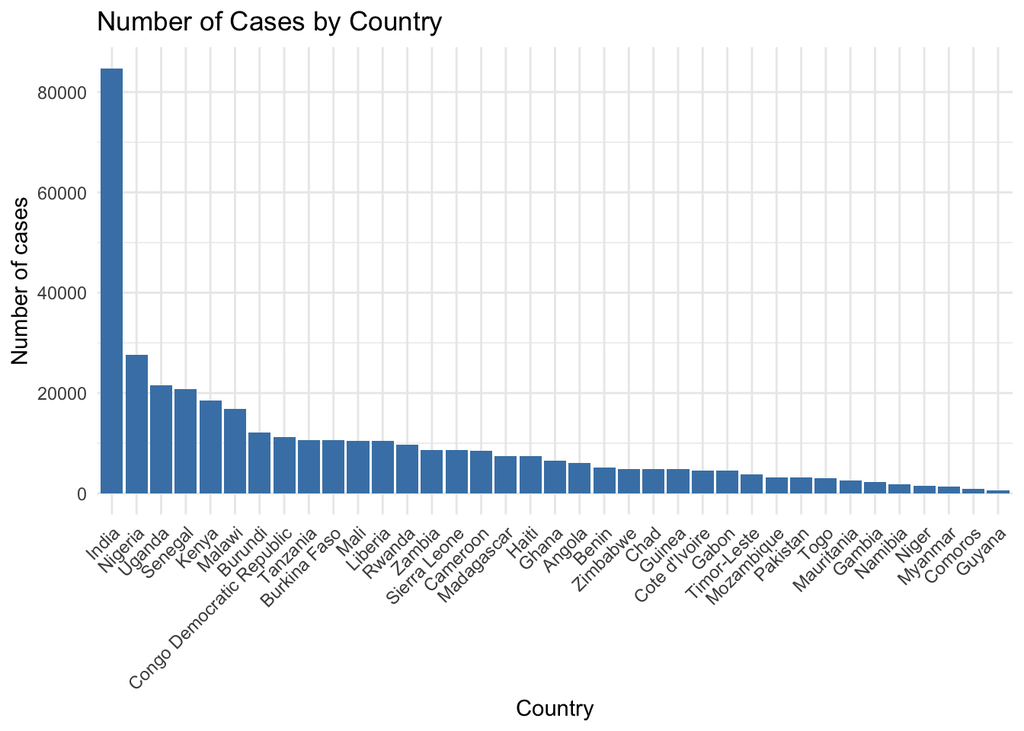

```r
library(ggplot2)

ggplot(country_count_all, aes(x = reorder(country,-n), y = n)) +
  geom_bar(stat = "identity", fill = "steelblue") +
  labs(title = "Number of Cases by Country", x = "Country", y = "Number of cases") +
  theme_minimal() +
  theme(axis.text.x = element_text(angle = 45, hjust = 1))
```

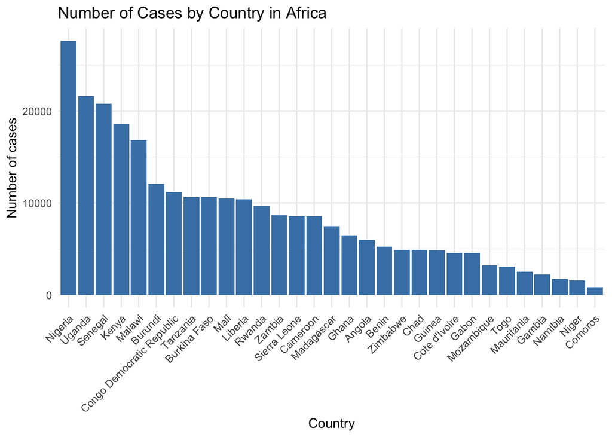

```r
ggplot(country_count, aes(x = reorder(country,-n), y = n)) +
  geom_bar(stat = "identity", fill = "steelblue") +
  labs(title = "Number of Cases by Country in Africa", x = "Country", y = "Number of cases") +
  theme_minimal() +
  theme(axis.text.x = element_text(angle = 45, hjust = 1))
```

Creating the country maps using sf world Had to find devtools to get the add ones install in order to run rnaturalearth supporting and will isolate Africa in the map

```r
library(sf)
library(rnaturalearth)
library(rnaturalearthdata)
sf_world <- ne_countries(scale= "large", returnclass= "sf")

world <- sf_world %>%
  filter(continent == "Africa")
```

Converting long & lat to sf objects to map those on a sf map will be called merged2_sf

```r
# merged2_sf <- st_as_sf(merged2, coords = c("longitude", "latitude"), crs = 4326)
```

Mapping the data into a sf world map for visualization of malaria survey locations

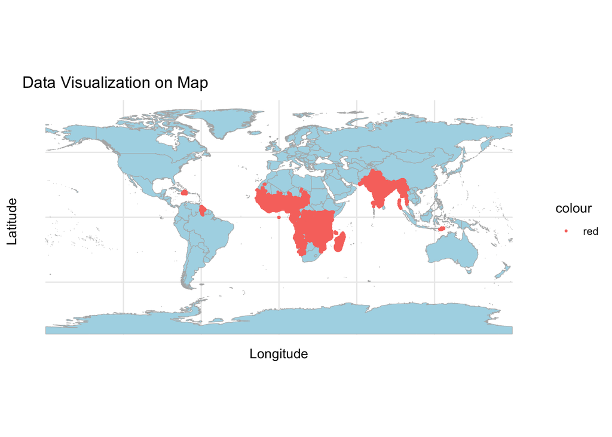

```r
ggplot() +
  geom_sf(data = sf_world, fill= "lightblue", color= "gray70") +
  geom_point(data = merged1, aes(x = longitude, y = latitude, color= "red"), size = 0.5) +
  theme_minimal() +
  labs(title = "Data Visualization on Map", x = "Longitude", y = "Latitude")
```

merged3 - data without NA in days_to_seek and with delayed variables.

```r
sum(is.na(merged2$days_to_seek))
```

```
## [1] 204172
```

```r
merged3 <- merged2 %>%
  mutate(days_to_seek = na_if(days_to_seek, "")) %>%
  filter(!is.na(days_to_seek))

merged3 <- merged3 %>%
  mutate(delayed = if_else(days_to_seek >= 1, 1, 0))
```

```r
str(merged3)
```

```
## 'data.frame':    37807 obs. of  60 variables:
##  $ program              : chr  "DHS" "DHS" "DHS" "DHS" ...
##  $ surveyid             : int  260 260 260 260 260 260 260 260 260 260 ...
##  $ phase                : chr  "DHS5" "DHS5" "DHS5" "DHS5" ...
##  $ surveyname           : chr  "ZW2005DHS" "ZW2005DHS" "ZW2005DHS" "ZW2005DHS" ...
##  $ country              : chr  "Zimbabwe" "Zimbabwe" "Zimbabwe" "Zimbabwe" ...
##  $ region               : chr  "Sub-Saharan Africa" "Sub-Saharan Africa" "Sub-Saharan Africa" "Sub-Saharan Africa" ...
##  $ subregion            : chr  "Eastern Africa" "Eastern Africa" "Eastern Africa" "Eastern Africa" ...
##  $ regionid             : int  2 3 4 2 2 2 5 2 2 5 ...
##  $ districtid           : int  NA NA NA NA NA NA NA NA NA NA ...
##  $ clusterid            : int  1060 726 8 806 198 806 954 699 48 954 ...
##  $ respondentid         : chr  "     1060192  1" "      726240  2" "        8308  2" "      806146  2" ...
##  $ childid              : int  2 1 1 1 1 1 1 1 1 1 ...
##  $ drug_base            : chr  "[\"fever/cough\"]" "[\"fever/cough\"]" "[\"fever/cough\"]" "[\"fever/cough\"]" ...
##  $ days_to_seek         : chr  "1" "9" "missing" "1" ...
```

[output cut: 46 more lines]

```r
sum(is.na(merged3$delayed))
```

```
## [1] 0
```

Seeing if there any spelliing mistakes in the countries

```r
print(unique(merged3$country))
```

```
##  [1] "Zimbabwe"      "Uganda"        "Zambia"        "Angola"
##  [5] "Madagascar"    "Kenya"         "Ghana"         "Nigeria"
##  [9] "Tanzania"      "Rwanda"        "Sierra Leone"  "Liberia"
## [13] "Malawi"        "Senegal"       "Burundi"       "Benin"
## [17] "Togo"          "Cameroon"      "Mali"          "Burkina Faso"
## [21] "Mozambique"    "Guinea"        "Gabon"         "Mauritania"
## [25] "Gambia"        "Cote d'Ivoire" "Niger"
```

delay_per - Checking the percentage of delayed and non delayed cases to get an idea

```r
delay_per <- merged3 %>%
  count(delayed) %>%
  mutate(percentage = n / sum(n) * 100)

delay_per
```

```
##   delayed     n percentage
## 1       0  8600   22.74711
## 2       1 29207   77.25289
```

Plotting the percentages to visualize the ratio

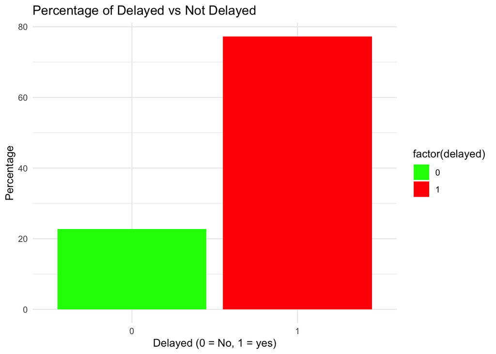

```r
ggplot(delay_per, aes(x = factor(delayed), y = percentage, fill = factor(delayed))) +
  geom_col() +
  scale_fill_manual(values = c("0" = "green", "1" = "red")) +
  labs(title = "Percentage of Delayed vs Not Delayed",
       x = "Delayed (0 = No, 1 = yes)",
       y = "Percentage") +
  theme_minimal()
```

This same factor on the Africa map to identify the areas with more delays and no delays To do that changing the delayed information as factors

```r
merged3$delayed_factor <- factor(merged3$delayed,
                                 levels = c(0,1),
                                 labels = c("Not Delayed", "Delayed"))

str(merged3)
```

```
## 'data.frame':    37807 obs. of  61 variables:
##  $ program              : chr  "DHS" "DHS" "DHS" "DHS" ...
##  $ surveyid             : int  260 260 260 260 260 260 260 260 260 260 ...
##  $ phase                : chr  "DHS5" "DHS5" "DHS5" "DHS5" ...
##  $ surveyname           : chr  "ZW2005DHS" "ZW2005DHS" "ZW2005DHS" "ZW2005DHS" ...
##  $ country              : chr  "Zimbabwe" "Zimbabwe" "Zimbabwe" "Zimbabwe" ...
##  $ region               : chr  "Sub-Saharan Africa" "Sub-Saharan Africa" "Sub-Saharan Africa" "Sub-Saharan Africa" ...
##  $ subregion            : chr  "Eastern Africa" "Eastern Africa" "Eastern Africa" "Eastern Africa" ...
##  $ regionid             : int  2 3 4 2 2 2 5 2 2 5 ...
##  $ districtid           : int  NA NA NA NA NA NA NA NA NA NA ...
##  $ clusterid            : int  1060 726 8 806 198 806 954 699 48 954 ...
##  $ respondentid         : chr  "     1060192  1" "      726240  2" "        8308  2" "      806146  2" ...
##  $ childid              : int  2 1 1 1 1 1 1 1 1 1 ...
##  $ drug_base            : chr  "[\"fever/cough\"]" "[\"fever/cough\"]" "[\"fever/cough\"]" "[\"fever/cough\"]" ...
##  $ days_to_seek         : chr  "1" "9" "missing" "1" ...
```

[output cut: 47 more lines]

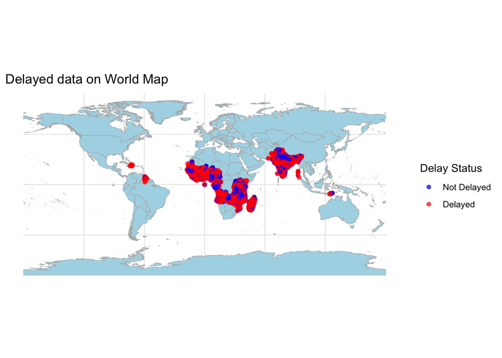

```r
merged1 <- merged1 %>%
  mutate(days_to_seek = na_if(days_to_seek, "")) %>%
  filter(!is.na(days_to_seek))

merged1 <- merged1 %>%
  mutate(delayed = if_else(days_to_seek >= 1, 1, 0))

merged1$delayed_factor <- factor(merged1$delayed,
                                 levels = c(0,1),
                                 labels = c("Not Delayed", "Delayed"))

merged1_sf <- st_as_sf(merged1, coords = c("longitude", "latitude"), crs = 4326)

ggplot() +
  geom_sf(data = sf_world, fill = "lightblue", color = "gray70") +
  geom_sf(data = merged1_sf, aes(color = delayed_factor), alpha = 0.7) +
  scale_color_manual(values = c("blue", "red")) +
  labs(title = "Delayed data on World Map",
       color = "Delay Status") +
  theme_minimal()
```

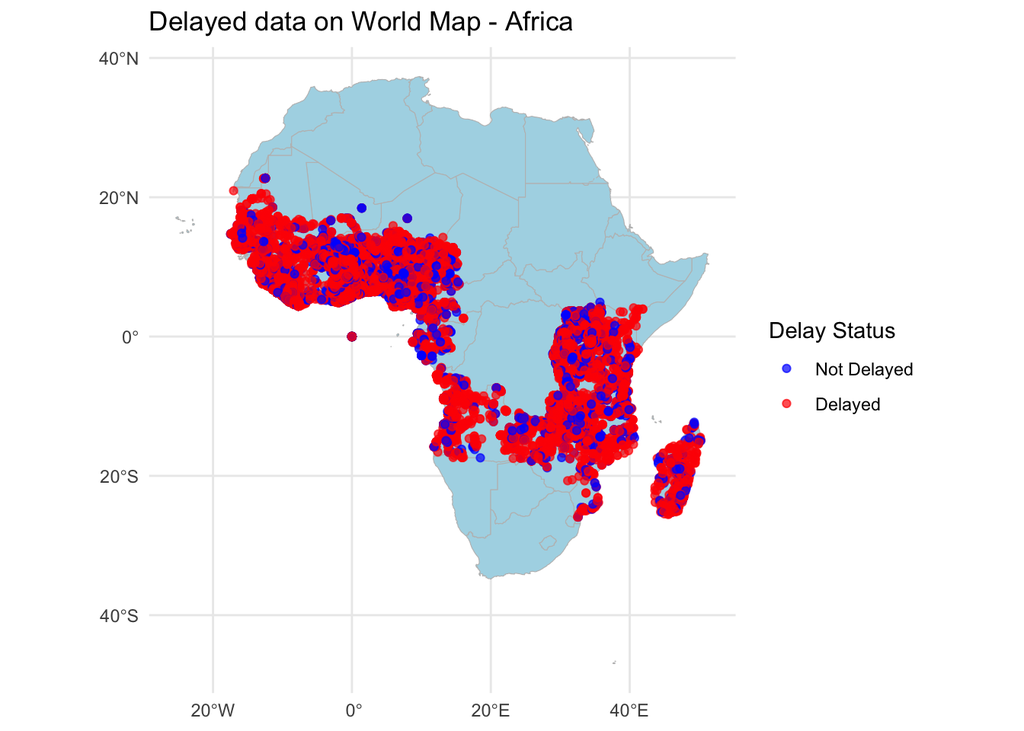

```r
merged3_sf <- st_as_sf(merged3, coords = c("longitude", "latitude"), crs = 4326)

ggplot() +
  geom_sf(data = world, fill = "lightblue", color = "gray") +
  geom_sf(data = merged3_sf, aes(color = delayed_factor), alpha = 0.7) +
  scale_color_manual(values = c("blue", "red")) +
  labs(title = "Delayed data on World Map - Africa",
       color = "Delay Status") +
  theme_minimal()
```

Same visualization without the use of sf

```r
# ggplot() +
#   geom_sf(data = world, fill = "lightblue", color = "gray60") +
#   geom_point(data = merged3, aes(x = longitude, y = latitude, color = delayed_factor), size = 0.5) +
#   scale_color_manual(values = c("blue", "red")) +
#   theme_minimal() +
#   labs(title = "Data in Africa Visualization on Map", x = "Longitude", y = "Latitude",
#        color = "Delay Status")
```

Surveys are done in areas as clusters. so clusters can have more than one observation. This can affect the accuracy of the reading as the percentage of delays in an area can be 100% if there is only one person in a cluster and that person had delays in their treatment. Hence checking the cluster information. Will call this “cluster_count”

```r
cluster_count <- merged3_sf %>%
  filter(!is.na(year)) %>% # removing NA values from existing columns
  group_by(program, surveyid, regionid, clusterid, country,delayed, delayed_factor, year) %>%
  summarise(count = n(), .groups = "drop") # this will count the number of rows per cluster
# So the clusters will separate by all these factors which can possibly can isolate actual clusters of surveys
head(cluster_count)
```

```
## Simple feature collection with 6 features and 9 fields
## Geometry type: POINT
## Dimension:     XY
## Bounding box:  xmin: 30.33173 ymin: -20.06439 xmax: 32.68743 ymax: -16.06165
## Geodetic CRS:  WGS 84
## # A tibble: 6 × 10
##   program surveyid regionid clusterid country delayed delayed_factor  year count
##   <chr>      <int>    <int>     <int> <chr>     <dbl> <fct>          <int> <int>
## 1 DHS          260        1      1126 Zimbab…       1 Delayed         2005     1
## 2 DHS          260        2        48 Zimbab…       0 Not Delayed     2005     1
## 3 DHS          260        2       198 Zimbab…       1 Delayed         2005     1
## 4 DHS          260        2       699 Zimbab…       0 Not Delayed     2005     1
## 5 DHS          260        2       699 Zimbab…       1 Delayed         2005     1
## 6 DHS          260        2       756 Zimbab…       1 Delayed         2005     1
## # ℹ 1 more variable: geometry <POINT [°]>
```

```r
str(cluster_count)
```

```
## sf [15,245 × 10] (S3: sf/tbl_df/tbl/data.frame)
##  $ program       : chr [1:15245] "DHS" "DHS" "DHS" "DHS" ...
##  $ surveyid      : int [1:15245] 260 260 260 260 260 260 260 260 260 260 ...
##  $ regionid      : int [1:15245] 1 2 2 2 2 2 2 2 3 4 ...
##  $ clusterid     : int [1:15245] 1126 48 198 699 699 756 806 1060 726 8 ...
##  $ country       : chr [1:15245] "Zimbabwe" "Zimbabwe" "Zimbabwe" "Zimbabwe" ...
##  $ delayed       : num [1:15245] 1 0 1 0 1 1 1 1 1 1 ...
##  $ delayed_factor: Factor w/ 2 levels "Not Delayed",..: 2 1 2 1 2 2 2 2 2 2 ...
##  $ year          : int [1:15245] 2005 2005 2005 2005 2005 2005 2005 2005 2005 2005 ...
##  $ count         : int [1:15245] 1 1 1 1 1 1 2 2 1 1 ...
##  $ geometry      :sfc_POINT of length 15245; first list element:  'XY' num [1:2] 32.7 -20.1
##  - attr(*, "sf_column")= chr "geometry"
##  - attr(*, "agr")= Factor w/ 3 levels "constant","aggregate",..: NA NA NA NA NA NA NA NA NA
##   ..- attr(*, "names")= chr [1:9] "program" "surveyid" "regionid" "clusterid" ...
```

Visualization for a better understanding

[figure not shown]

```r
ggplot(cluster_count, aes(x = factor(year), y = count)) +
  geom_bar(stat = "Identity", fill = "skyblue", color = "blue") +
  labs(title = "Number of Entries Per Year",
       x = "Survey year",
       y = "Count") +
  theme_minimal() +
  theme(axis.text.x = element_text(angle = 90, hjust = 1))
```

To get an idea of how many children are in a cluster, getting the count. Aggregate the data

```r
cluster_count_agg <- cluster_count %>%
  group_by(country, year) %>%
  summarise(total_clusters = sum(count, na.rm = TRUE)) %>%
  ungroup()
```

The total values in a plot for easy understanding below

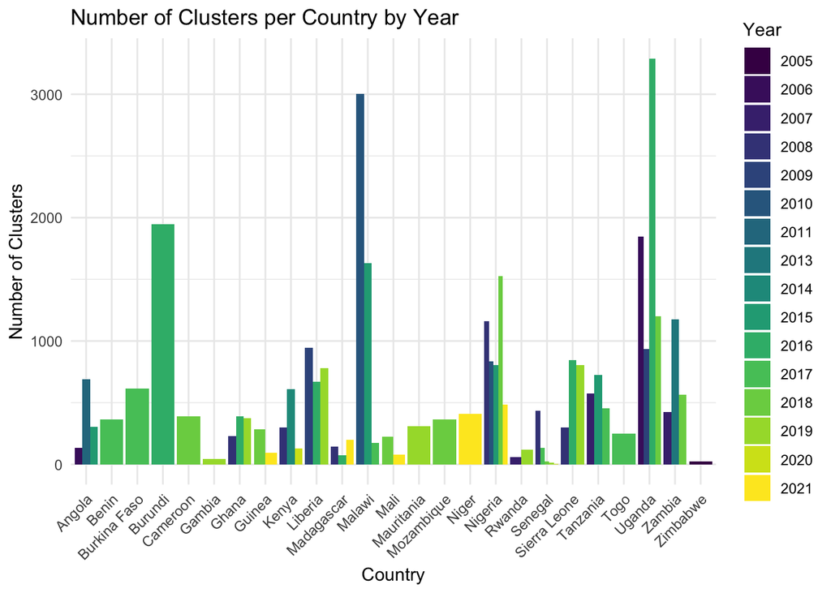

```r
ggplot(cluster_count_agg, aes(x = country, y = total_clusters, fill = factor(year))) +
  geom_bar(stat = "identity", position = "dodge") +
    scale_fill_viridis_d() +
  labs(title = "Number of Clusters per Country by Year",
       x = "Country",
       y = "Number of Clusters",
       fill = "Year") +
  theme_minimal() +
  theme(axis.text.x = element_text(angle = 45, hjust = 1))
```

Clusters may have different numbers of cases depends on the survey carried on. Hence it is important to see the cluster information based on the numbers

```r
cluster_count <- cluster_count %>%
  mutate(cluster_size_category = case_when(
    count == 1 ~ "1",
    count == 2 ~ "2",
    count == 3 ~ "3",
    count == 4 ~ "4",
    count == 5 ~ "5",
    count > 5 ~ ">5"
  ))
```

Calculating the proportions in the cluster data

```r
proportion_table <- cluster_count %>%
  group_by(cluster_size_category) %>%
  summarise(n = n()) %>%
  mutate(proportion = n / sum(n) * 100)
```

Calculating the proportions based on the country

```r
country_proportion_table <- cluster_count %>%
  group_by(country, year) %>%
  mutate(total_count_country = sum(count)) %>%
  group_by(country, clusterid) %>%
  summarise(cluster_count = sum(count),
            proportion = cluster_count/ first(total_count_country) * 100) %>%
  ungroup()
```

calculating the proportions of the sum of the clusters

```r
cluster_count_agg <- cluster_count_agg %>%
  group_by(country) %>%
  mutate(proportion = total_clusters / sum(total_clusters)* 100) %>%
  ungroup()

str(country_proportion_table)
```

```
## sf [8,137 × 5] (S3: sf/tbl_df/tbl/data.frame)
##  $ country      : chr [1:8137] "Angola" "Angola" "Angola" "Angola" ...
##  $ clusterid    : int [1:8137] 1 2 3 4 5 6 7 8 9 10 ...
##  $ cluster_count: int [1:8137] 6 5 4 9 12 2 7 2 8 9 ...
##  $ proportion   : num [1:8137] 4.44 3.7 2.96 6.67 8.89 ...
##  $ geometry     :sfc_GEOMETRY of length 8137; first list element:  'XY' num [1:2, 1:2] 13.5 13.9 -12.4 -12.2
##  - attr(*, "sf_column")= chr "geometry"
##  - attr(*, "agr")= Factor w/ 3 levels "constant","aggregate",..: NA NA NA NA
##   ..- attr(*, "names")= chr [1:4] "country" "clusterid" "cluster_count" "proportion"
```

View the results of the cluster distribution based on the year and the country on a stack chart

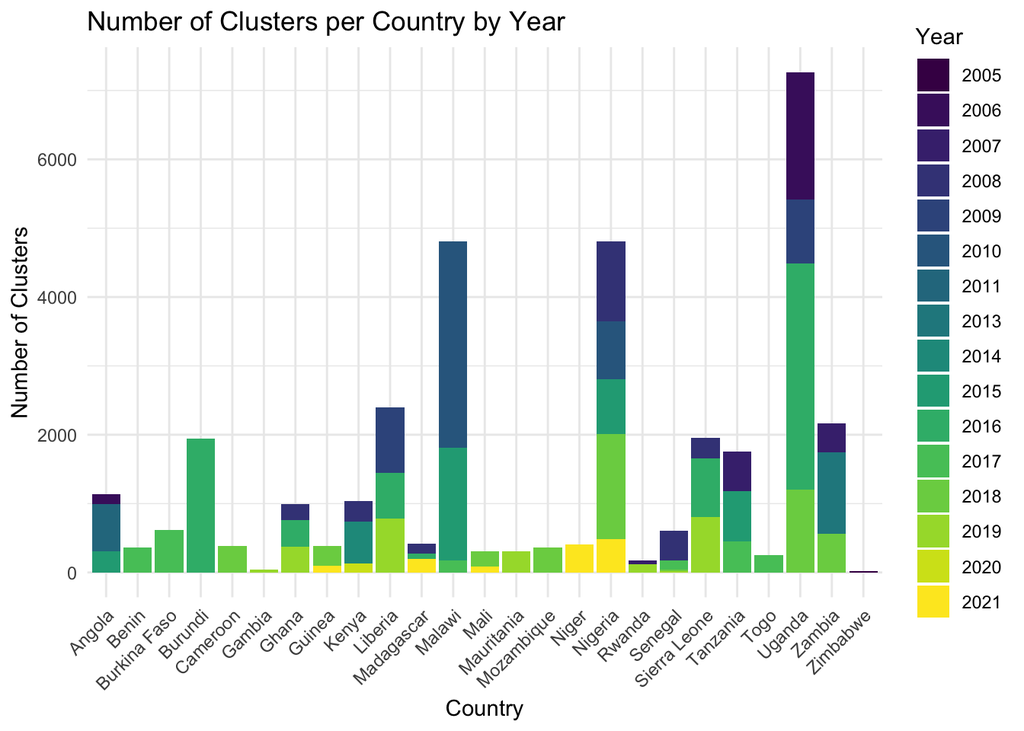

```r
ggplot(cluster_count_agg, aes(x = country, y = total_clusters, fill = factor(year))) +
  geom_bar(stat = "identity") +
  scale_fill_viridis_d() +
  labs(title = "Number of Clusters per Country by Year",
       x = "Country",
       y = "Number of Clusters",
       fill = "Year") +
  theme_minimal() +
  theme(axis.text.x = element_text(angle = 45, hjust = 1))
```

Summing total_clusters per country

```r
total_clusters_per_country <- cluster_count_agg %>%
  group_by(country) %>%
  summarise(total = sum(total_clusters))
```

Cluster distribution based on the year and country as proportions. This shows the total amount of clusters on the top while showing the percentage of the clusters based on the year for each country

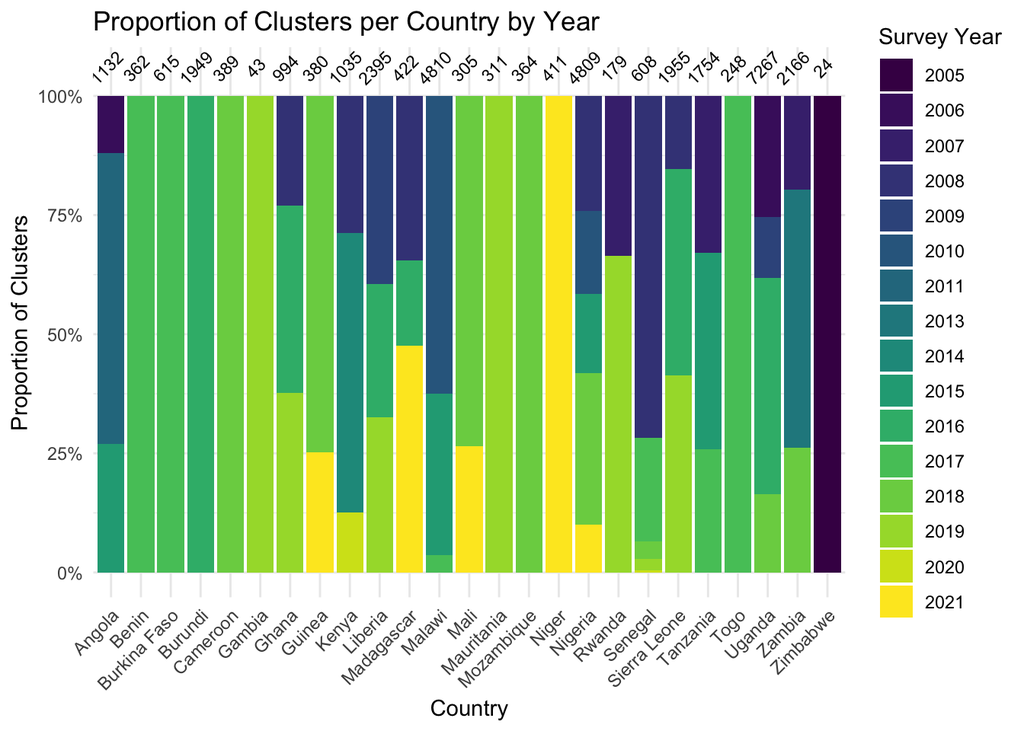

```r
library(scales)
ggplot(cluster_count_agg, aes(x = country, y = total_clusters, fill = factor(year))) +
  geom_bar(stat = "identity", position = "fill") +
  scale_fill_viridis_d() +
  scale_y_continuous(labels = percent_format()) +
  labs(title = "Proportion of Clusters per Country by Year",
       x = "Country",
       y = "Proportion of Clusters",
       fill = "Survey Year") +
  theme_minimal() +
  theme(axis.text.x = element_text(angle = 45, hjust = 1)) +
  geom_text(data = total_clusters_per_country,
            aes(x = country, y = 1.05, label = total),
            inherit.aes = FALSE, size = 3, angle = 45, vjust = 0)
```

Convert cluster size category to a factor to maintain order in the plot

```r
proportion_table$cluster_size_category <- factor(proportion_table$cluster_size_category,
                                                 levels = c("1", "2", "3", "4", "5", ">5"))
```

Creating a bar chart with cluster categories and counts

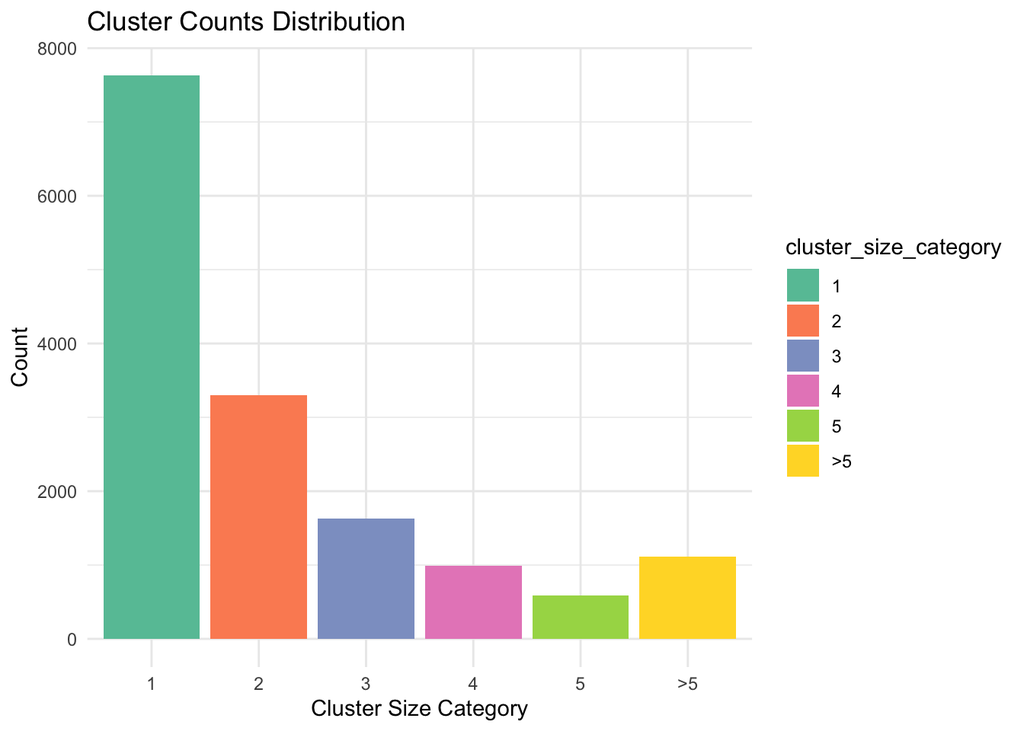

```r
ggplot(proportion_table, aes(x = cluster_size_category, y = n, fill = cluster_size_category)) +
  geom_bar(stat = "identity") +
  labs(title = "Cluster Counts Distribution", x = "Cluster Size Category", y = "Count") +
  theme_minimal() +
  scale_fill_brewer(palette = "Set2")
```

Creating a bar chart with cluster categories and counts but the bar chart based on the proportions which is basically the same chart but as precentage

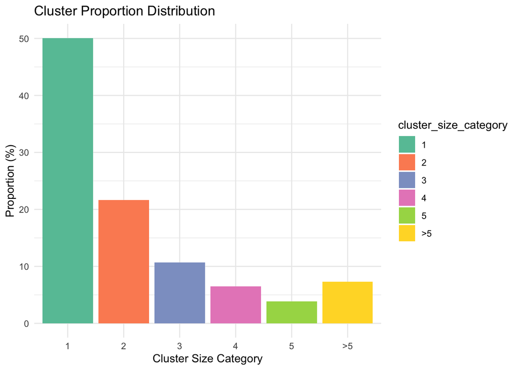

```r
ggplot(proportion_table, aes(x = cluster_size_category, y = proportion, fill = cluster_size_category)) +
  geom_bar(stat = "identity") +
  labs(title = "Cluster Proportion Distribution", x = "Cluster Size Category", y = "Proportion (%)") +
  theme_minimal() +
  scale_fill_brewer(palette = "Set2")
```

cluster categories and counts information on a world map. This shows all the cluster numbers (based on how many are in a cluster) as a proportion

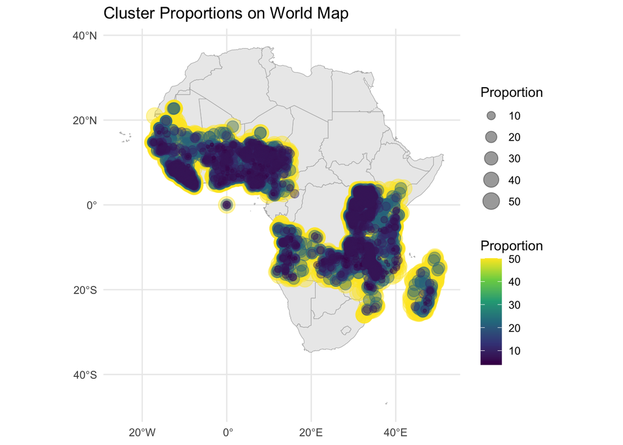

```r
ggplot() +
  geom_sf(data = world, fill = "grey92", color = "grey70") +
  geom_sf(data = proportion_table,
          aes(size = proportion, color = proportion),
          alpha = 0.4) +
  scale_size_continuous(range = c(1,6)) +
  scale_color_viridis_c() +
  labs(title = "Cluster Proportions on World Map",
       size = "Proportion",
       color = "Proportion") +
  theme_minimal()
```

Plotting based on the cluster id, countries and proportion. Just because the information is there. Readability of the plot is not that great

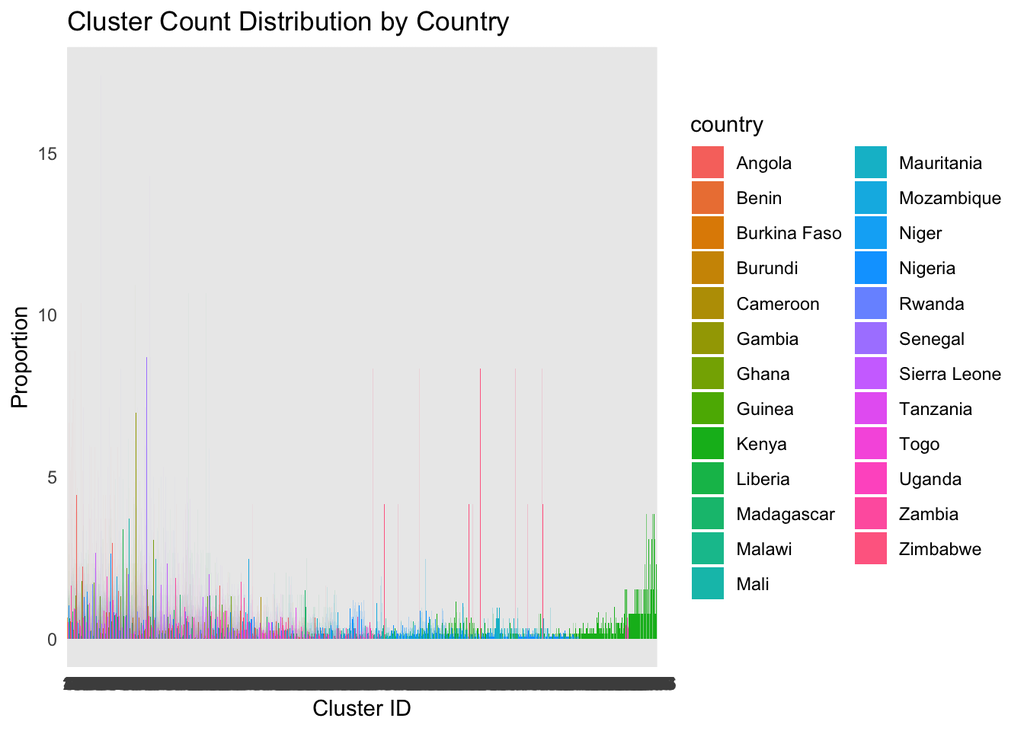

```r
# plotting based on the cluster id, countries and proportion
ggplot(country_proportion_table, aes(x = factor(clusterid), y = proportion, fill = country)) +
  geom_bar(stat = "identity", position = "dodge") +
  labs(title = "Cluster Count Distribution by Country", x = "Cluster ID", y = "Proportion") +
  theme_minimal()
```

Cluster count by country

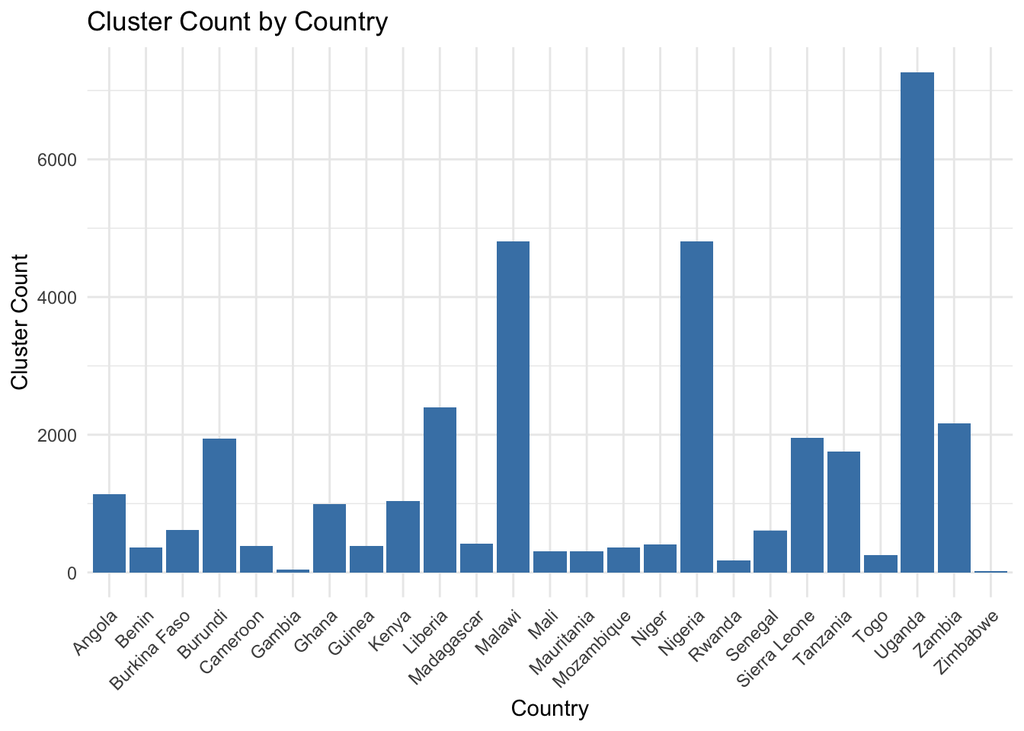

```r
ggplot(cluster_count_agg, aes(x = country, y = total_clusters)) +
  geom_bar(stat = "identity", fill = "steelblue") +
  labs(title = "Cluster Count by Country",
       x = "Country",
       y = "Cluster Count") +
  theme_minimal() +
  theme(axis.text.x = element_text(angle = 45, hjust = 1))
```

Plot the world map and overlay the cluster proportion points. This shows the proportion as a whole from the full clusters. Example: from 100% how much is clusderid 1 has.

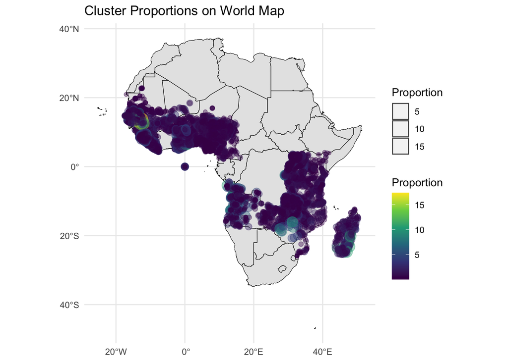

```r
ggplot() +
  geom_sf(data = world, fill = "grey90", color = "black") +
  geom_sf(data = country_proportion_table,
          aes(size = proportion, color = proportion),
          alpha = 0.4) +
  scale_size_continuous(range = c(1,6)) +
  scale_color_viridis_c() +
  labs(title = "Cluster Proportions on World Map",
       size = "Proportion",
       color = "Proportion") +
  theme_minimal()
```

Separating the cluster information based on the delayed factor

```r
cluster_counts_delay <- cluster_count %>%
  group_by(program,country, year, surveyid, delayed, delayed_factor) %>%
  summarise(cluster_counts = n(), .groups = "drop")
```

Computing the Proportions per country and year based on delayed information

```r
cluster_counts_delay <- cluster_counts_delay %>%
  group_by(country) %>%
  mutate(total_clusters = sum(cluster_counts),
         proportion = cluster_counts/ total_clusters*100)
```

Visualizing the delayed information based country

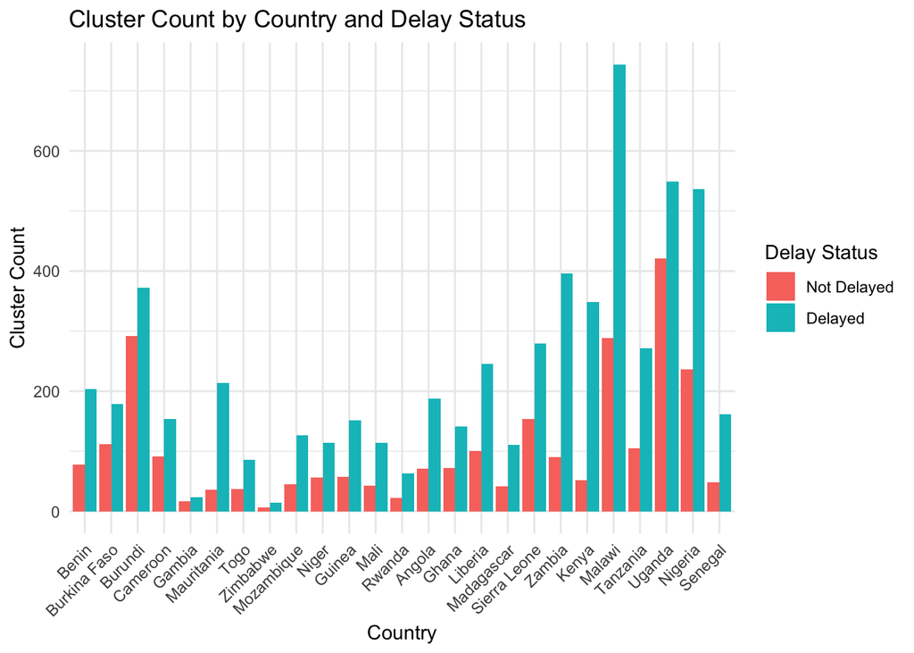

```r
ggplot(cluster_counts_delay, aes(x = reorder(country, -proportion), y = cluster_counts, fill = delayed_factor)) +
  geom_bar(stat = "identity", position = "dodge") +  # Side-by-side bars
  labs(title = "Cluster Count by Country and Delay Status",
       x = "Country",
       y = "Cluster Count",
       fill = "Delay Status") +
  theme_minimal() +
  theme(axis.text.x = element_text(angle = 45, hjust = 1))
```

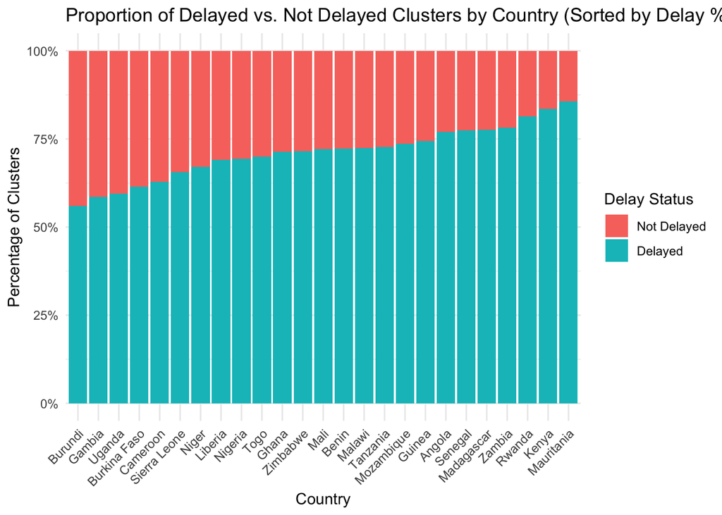

```r
# Remove geometry temporarily
cluster_counts_delay_no_geom <- st_drop_geometry(cluster_counts_delay)

library(tidyr)
# Calculate the delayed percentage per country
delay_percentage <- cluster_counts_delay_no_geom %>%
  group_by(country, delayed_factor) %>%
  summarise(total = sum(cluster_counts), .groups = "drop") %>%
  pivot_wider(names_from = delayed_factor, values_from = total, values_fill = list(total = 0)) %>%
  mutate(delayed_percentage = `Delayed` / (`Not Delayed` + `Delayed`)) %>%
  select(country, delayed_percentage)  # Keep only relevant columns

# Merge back with the original sf object (keeping geometry)
cluster_counts_delay <- cluster_counts_delay %>%
  left_join(delay_percentage, by = "country")

# Reorder countries based on delayed percentage
ggplot(cluster_counts_delay, aes(x = reorder(country, delayed_percentage), y = proportion, fill = delayed_factor)) +
  geom_bar(stat = "identity", position = "fill") +  # Stacked bar chart (normalized to 100%)
  scale_y_continuous(labels = percent_format(scale = 100)) +  # Show as percentage
  labs(title = "Proportion of Delayed vs. Not Delayed Clusters by Country (Sorted by Delay %)",
       x = "Country",
       y = "Percentage of Clusters",
       fill = "Delay Status") +
  theme_minimal() +
  theme(axis.text.x = element_text(angle = 45, hjust = 1))  # Rotate x-axis labels
```

Trying to separate by year as well

```r
cluster_counts_delay_year <- cluster_counts_delay %>%
  group_by(country, year) %>%
  mutate(total_clusters = sum(cluster_counts),
         proportion = cluster_counts/ total_clusters*100)
```

Proportion of Cluster Counts by Country, Year, and Delay Status in a plot. This shows all the delayed and non delayed infromation which kind of looks confusing

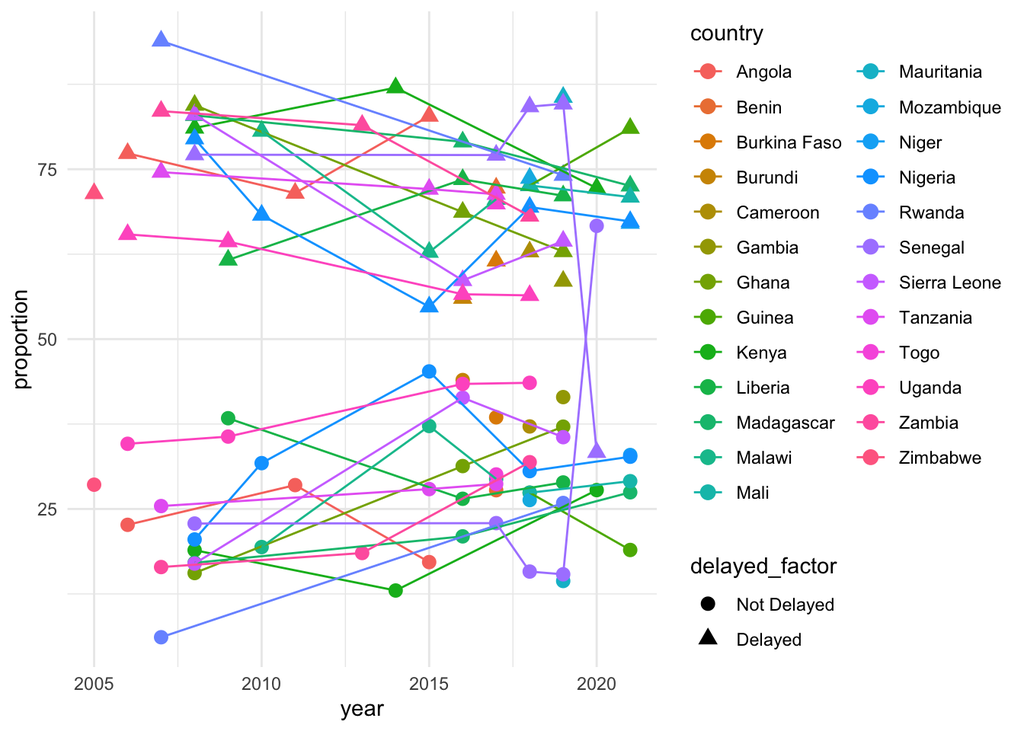

```r
ggplot(cluster_counts_delay_year, aes(x = year, y = proportion, color = country, shape = delayed_factor)) +
  geom_point(size = 3) +
  geom_line() +
  theme_minimal()
```

Proportion of Cluster Counts by Country, Year, and Delay Status in a plot to make it look less complicated

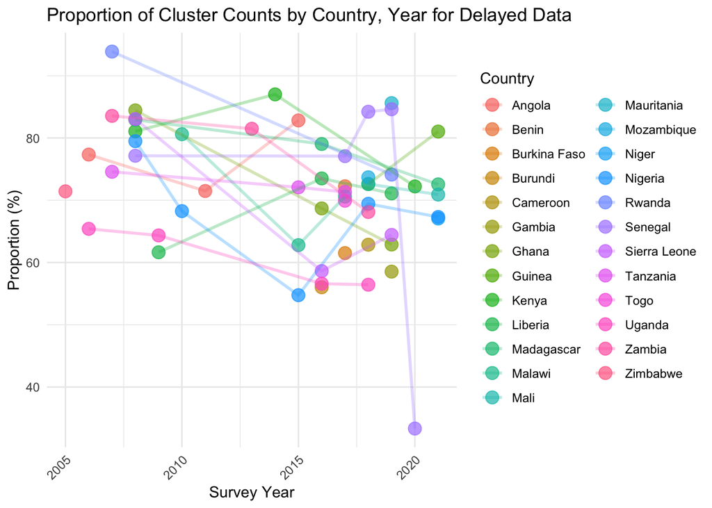

```r
ggplot(cluster_counts_delay_year %>% filter(delayed_factor=="Delayed"),
       aes(x = year, y = proportion, color = country)) +
  geom_point(size = 4, alpha = 0.7) +
  geom_line(size = 1, alpha = 0.3) +
  labs(title = "Proportion of Cluster Counts by Country, Year for Delayed Data",
       x = "Survey Year",
       y = "Proportion (%)",
       color = "Country"
       ) +
  theme_minimal() +
  theme(axis.text.x = element_text(angle = 45, hjust = 1))
```

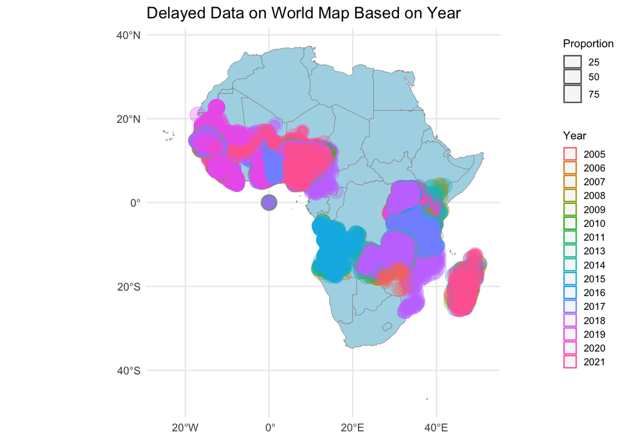

```r
ggplot() +
  geom_sf(data = world, fill = "lightblue", color = "gray60") +
  geom_sf(data = cluster_counts_delay_year, aes(color = factor(year), size = proportion), alpha = 0.3) +
  scale_fill_viridis_d() +
  labs(title = "Delayed Data on World Map Based on Year",
       color = "Year",
       size = "Proportion") +
  theme_minimal() +
  theme(
    legend.position = c(1.25, 0.55),  # Moves legend inside the plot (adjust as needed)
    legend.key.size = unit(0.4, "cm"),  # Decrease legend key size
    legend.text = element_text(size = 8),  # Reduce text size
    legend.title = element_text(size = 9),  # Reduce title size
    legend.spacing.x = unit(0.3, 'cm')  # Reduce spacing between legend items
  ) +
  guides(size = guide_legend())
```

```r
library(gganimate)
animated_map <- ggplot() +
  geom_sf(data = world, fill = "lightblue", color = "gray60") +
  geom_sf(data = cluster_counts_delay_year, aes(color = factor(year), size = proportion), alpha = 0.7) +
  scale_color_viridis_d() +
  labs(title = "Delayed Data on World Map (Year: {closest_state})") +
  theme_minimal() +
  theme(
    legend.position = "none"  # 👈 Removes legend entirely
  ) +
  transition_states(year, transition_length = 1, state_length = 2)

# Render the animation
#animate(animated_map, fps = 5, duration = 10, width = 800, height = 600, renderer = gifski_renderer("animated_map.gif"))
```

```r
library(viridis)
```